# How to guide – Language model and keyword searches

Author

Zach Dickson

## In this notebook, I’ll demonstrate how to use the multilingual language model I created to get the sentiment of newspaper headlines. I’ll also show how to create time-series data according to topics using keywords.

Feel free to copy this notebook and use it for yourself. If you do not already have python installed already on your computer and you don’t want to install it ([how to check](https://stackoverflow.com/questions/56715476/how-do-i-test-if-python-is-installed-on-windows-10-and-run-an-exe-to-install)), then you can use this notebook in [Google Colab](https://colab.research.google.com/).

This option can be especially appealing if you want to use the language model on lots of text, because Google Colab allows you to use a GPU, which increases the speed of the model significantly. I’ll demonstrate how to do this at the end also.

### I created a new dataset that combines all the newspapers collected for all five countries. I’ve also cleaned this data so that it is ready to use exactly like I do in this notebook. Feel free to use it as you wish, but please don’t overwrite the dataset in the dropbox if you make manipulations so that others can similarly follow the same steps

### Notes:

- The newspapers dataset is located in …/Dropbox/COVIDEU/WP 1 Borders & Mobility/Analysis/newspaper_analysis/data/
- The newspaper dataset is called “newspaper_data_all.csv”
- This notebook file is located in …/Dropbox/COVIDEU/WP 1 Borders & Mobility/Analysis/newspaper_analysis/code/newspaper_sentiment_attention_tutorial.ipynb
  - feel free to copy it and then modify it however you want (just make a copy of it first!)

```python
##### if you're using google colab, you'll need to change the file location of the dataset to the appropriate location in order
#### There are a few ways to do this -- one would be to mount your own google drive. Another would be to upload to newspaper file in the Colab notebook in the left hand column.





import pandas as pd # import necessary library
import numpy as np # import necessary library

pd.set_option('display.max_columns', 50)  ## set max columns to display as 50

df = pd.read_csv('/content/drive/MyDrive/COVIDEU project/newspaper_tutorial/newspaper_data_all.csv')  ## read in the dataset. See the first comment in this box of code
df.date = pd.to_datetime(df.date)  # set date column to pandas version of date

df.newspaper = df.newspaper.str.replace('_', ' ').str.title() ## these are just changes to the names of the newspapers for presentation purposes
df.country = df.country.str.title().str.replace('Uk','UK') ## these are just changes to the names of the newspapers for presentation purposes
```

### **Note:** if you have trouble importing the newspapers dataset, see the following [tutorial](https://www.geeksforgeeks.org/ways-to-import-csv-files-in-google-colab/).

## First five rows of the dataset:

```python
df.head()
```

|  | date | link | title | newspaper | country |
| --- | --- | --- | --- | --- | --- |
| 0 | 2020-01-01 | https://sport.fakt.pl/inne-sporty/david-stern-... | Zmarł były komisarz ligi NBA David Stern | Fakt | Poland |
| 1 | 2020-01-01 | https://www.fakt.pl/polityka/sylwester-polityk... | "Grzeczny" sylwester polityków. Tylko Jaki się... | Fakt | Poland |
| 2 | 2020-01-01 | https://www.fakt.pl/wydarzenia/polska/zaglada-... | Zagłada ptaków w Polsce. W środę zabijały je w... | Fakt | Poland |
| 3 | 2020-01-01 | https://sport.fakt.pl/pilka-nozna/nietypowa-ci... | Nietypowa cieszynka piłkarzy Cracovii. Przebra... | Fakt | Poland |
| 4 | 2020-01-01 | https://www.fakt.pl/plotki/z-kim-ania-z-rolnik... | Z kim Ania z „Rolnik szuka żony” spędziła sylw... | Fakt | Poland |

## I’ll visualise some basic descriptive statistics for the dataset

Articles per newspaper:

```python
df.groupby('newspaper').size()
```

```
newspaper
Abc Spain               50666
Bild                   204491
De Telegraaf           176781
De Welt                 42199
El Mundo                39738
El Pais                 67419
Fakt                    89627
Gazeta Wyborcza         27390
Guardian               149828
Nrc                     49361
Rzeczpospolita          20647
Suddeutsche Zeitung    586495
Uk Sun                 128994
Uk Times                32062
Volkskrant              62579
dtype: int64
```

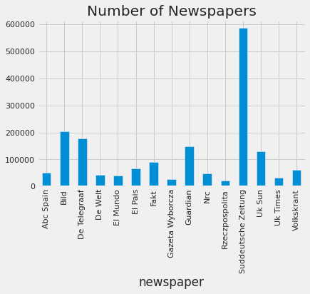

```python
import seaborn as sns
import matplotlib.pyplot as plt

sns.set_theme('notebook')
plt.style.use('fivethirtyeight')

df.groupby('newspaper').size().plot(kind='bar')
plt.title('Number of Newspapers')
```

Articles per newspaper, per country

```python
df.groupby(['country','newspaper']).size()
```

```
country      newspaper
Germany      Bild                   204491
             De Welt                 42199
             Suddeutsche Zeitung    586495
Netherlands  De Telegraaf           176781
             Nrc                     49361
             Volkskrant              62579
Poland       Fakt                    89627
             Gazeta Wyborcza         27390
             Rzeczpospolita          20647
Spain        Abc Spain               50666
             El Mundo                39738
             El Pais                 67419
UK           Guardian               149828
             Uk Sun                 128994
             Uk Times                32062
dtype: int64
```

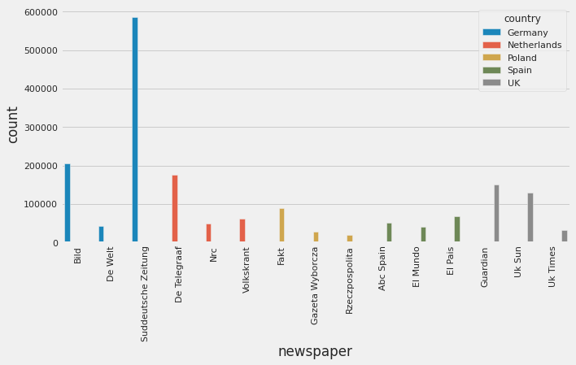

```python
x = pd.DataFrame(df.groupby(['country','newspaper']).size()).reset_index().rename(columns={0:'count'})

plt.figure(figsize=(10,5))

sns.barplot(x='newspaper', y='count', hue='country', data=x)
plt.xticks(rotation=90)
```

# 1: How to get the sentiment of a newspaper headline title

### I’ve trained a multilingual langauge model to predict the sentiment of news headlines. I’ve made the model publicly available at [HuggingFace](https://huggingface.co/z-dickson/multilingual_sentiment_newspaper_headlines). Huggingface is great because we can now import the language model from any notebook and there is no limit on the number of people who can use it at the same time. If you want to read more about the details of the model, see the following [link](https://huggingface.co/z-dickson/multilingual_sentiment_newspaper_headlines).

```python
## example code
import torch
from transformers import AutoTokenizer, AutoModelForSequenceClassification, TextClassificationPipeline,TFAutoModelForSequenceClassification, AutoTokenizer  ## imports necessary libraries (if these cannot be imported, then you must first install them.)
tokenizer = AutoTokenizer.from_pretrained("z-dickson/multilingual_sentiment_newspaper_headlines")     ## imports the tokenizer from the online model
m1 = TFAutoModelForSequenceClassification.from_pretrained("z-dickson/multilingual_sentiment_newspaper_headlines") ## imports the langauge model
sentiment_classifier = TextClassificationPipeline(tokenizer=tokenizer, model=m1)  ## creates a classifier based on the langauge model

sentiment_classifier('text we want to get the sentiment for')  ## classifies the text we want to get the sentiment for
```

## In the next cell, I’ll run the same code to import the model. You’ll likely need to install the necessary libraries on your machine or in google colab. These can easily be done by running the following code in a single cell:

```python
pip install transformers
```

```python
pip install transformers
```

```python
import torch
from transformers import AutoTokenizer, AutoModelForSequenceClassification, TextClassificationPipeline,TFAutoModelForSequenceClassification, AutoTokenizer


tokenizer = AutoTokenizer.from_pretrained("z-dickson/multilingual_sentiment_newspaper_headlines")
model = TFAutoModelForSequenceClassification.from_pretrained("z-dickson/multilingual_sentiment_newspaper_headlines")
sentiment_classifier = TextClassificationPipeline(tokenizer=tokenizer, model=model, device=0)
```

[output not shown]

## Now that we have imported the model into our notebook and have created the classifier, we can classify different headlines.

In German, the headline is as follows:

- Düsseldorf: Mann von jungem Messerstecher nach Streit schwer verletzt
- English: Dusseldorf: Man seriously injured by young knife man after argument

### We’ll pass the headline into the classifier in German using

```python
#example
sentiment_classifier('Mann von jungem Messerstecher nach Streit schwer verletzt')
```

The result is as follows:

```python
sentiment_classifier('Mann von jungem Messerstecher nach Streit schwer verletzt')
```

```
[{'label': 'negative', 'score': 0.9974108338356018}]
```

## The estimated sentiment is negative, and the model is very confident indicating a score of .99xxx. What we’re interested in is the sentiment label `negative`

## Let’s try the same thing in English, using the following:

```python
#example
sentiment_classifier('Man seriously injured by young knife man after argument')
```

### The only thing we change is the text, which I simply translated to English using google translate in a browser

The result is nearly identical

```python
sentiment_classifier('Man seriously injured by young knife man after argument')
```

```
[{'label': 'negative', 'score': 0.9988270401954651}]
```

Next, I’ll work through some examples that you might want to use in an analysis

# Worked Example #1

### In this example, I’ll show how to use the model to get the sentiment of multiple newspaper headlines

#### If you want to know how to get a a new dataset of headlines according to a specific search criteria, then see the next worked example.

## For the example, we’ll generate a list of headlines at random. The dataset will include ten rows with different headlines

here’s the dataset:

```python
headline_example = df.sample(10)

headline_example
```

|  | date | link | title | newspaper | country |
| --- | --- | --- | --- | --- | --- |
| 1308906 | 2021-10-27 | https://www.sueddeutsche.de/muenchen/1918-revo... | Demokraten der ersten Stunde | Suddeutsche Zeitung | Germany |
| 362058 | 2022-12-13 | https://www.thesun.co.uk/news/20743250/influen... | WarningJABS HORROR Model disfigured after dent... | Uk Sun | UK |
| 278800 | 2021-12-31 | https://www.theguardian.com/world/2021/dec/31/... | UK government’s Covid advisers enduring ‘tidal... | Guardian | UK |
| 1007565 | 2020-07-31 | https://www.sueddeutsche.de/politik/usa-ambiti... | Ambitionen auf Höheres | Suddeutsche Zeitung | Germany |
| 892201 | 2020-02-04 | https://www.sueddeutsche.de/muenchen/fuerstenf... | Die Wege des Coronavirus | Suddeutsche Zeitung | Germany |
| 408310 | 2017-06-14 | https://www.thesun.co.uk/news/3796254/female-t... | 'sex' teacher in court Maths teacher, 25, accu... | Uk Sun | UK |
| 961994 | 2020-05-19 | https://www.sueddeutsche.de/sport/basketball-f... | Skyliners freuen sich auf Basketball-Turnier | Suddeutsche Zeitung | Germany |
| 784958 | 2021-05-08 | /cultura/2021-05-08/tiempos-aquellos-cuando-la... | Tiempos aquellos cuando la izquierda era guapa... | El Pais | Spain |
| 967568 | 2020-05-26 | https://www.sueddeutsche.de/gesundheit/krankhe... | Betreiber und Prostituierte fordern Öffnung vo... | Suddeutsche Zeitung | Germany |
| 953098 | 2020-05-06 | https://www.sueddeutsche.de/panorama/kriminali... | Jugendlicher attackiert Polizisten nach Party-... | Suddeutsche Zeitung | Germany |

## I’ll write a function below that will take in a dataset like the one we have above, and return the same dataset but it will include columns for the sentiment of each article title. The only thing you need to do to get the result is to provide the name of the dataset (in the form of the above) in brackets with the name of the function (`sentiment_analysis`).

## For example:

```python
#example
sentiment_analysis(headline_example)
```

### returns the following:

```python
from logging import raiseExceptions


def sentiment_analysis(dataset, date_start=None, date_end=None):
  x = dataset.copy()
  try:
    if date_start != None:
      x.date = pd.to_datetime(x.date)
      x = x.loc[(x.date <= f'{date_end}') & (x.date >= f'{date_start}')]
    sentiment_list = []
    sentiment = sentiment_classifier(x.title.to_list())
    sentiment_list.append(sentiment)
    x['sentiment'] = sentiment
    x['sentiment_label'] = x.sentiment.apply(lambda x: x['label'])
    return x
  except TypeError:
    print("ERROR: ensure date_start and date_end are in the format Year-Month-Day. For example: 2020-01-08")
```

```python
sentiment_analysis(headline_example)
```

|  | date | link | title | newspaper | country | sentiment | sentiment_label |
| --- | --- | --- | --- | --- | --- | --- | --- |
| 1308906 | 2021-10-27 | https://www.sueddeutsche.de/muenchen/1918-revo... | Demokraten der ersten Stunde | Suddeutsche Zeitung | Germany | {'label': 'neutral', 'score': 0.8793636560440063} | neutral |
| 362058 | 2022-12-13 | https://www.thesun.co.uk/news/20743250/influen... | WarningJABS HORROR Model disfigured after dent... | Uk Sun | UK | {'label': 'negative', 'score': 0.9988217949867... | negative |
| 278800 | 2021-12-31 | https://www.theguardian.com/world/2021/dec/31/... | UK government’s Covid advisers enduring ‘tidal... | Guardian | UK | {'label': 'negative', 'score': 0.9676236510276... | negative |
| 1007565 | 2020-07-31 | https://www.sueddeutsche.de/politik/usa-ambiti... | Ambitionen auf Höheres | Suddeutsche Zeitung | Germany | {'label': 'positive', 'score': 0.5634114146232... | positive |
| 892201 | 2020-02-04 | https://www.sueddeutsche.de/muenchen/fuerstenf... | Die Wege des Coronavirus | Suddeutsche Zeitung | Germany | {'label': 'positive', 'score': 0.721671462059021} | positive |
| 408310 | 2017-06-14 | https://www.thesun.co.uk/news/3796254/female-t... | 'sex' teacher in court Maths teacher, 25, accu... | Uk Sun | UK | {'label': 'negative', 'score': 0.9989349246025... | negative |
| 961994 | 2020-05-19 | https://www.sueddeutsche.de/sport/basketball-f... | Skyliners freuen sich auf Basketball-Turnier | Suddeutsche Zeitung | Germany | {'label': 'positive', 'score': 0.7529820799827... | positive |
| 784958 | 2021-05-08 | /cultura/2021-05-08/tiempos-aquellos-cuando-la... | Tiempos aquellos cuando la izquierda era guapa... | El Pais | Spain | {'label': 'neutral', 'score': 0.9832658767700195} | neutral |
| 967568 | 2020-05-26 | https://www.sueddeutsche.de/gesundheit/krankhe... | Betreiber und Prostituierte fordern Öffnung vo... | Suddeutsche Zeitung | Germany | {'label': 'neutral', 'score': 0.883710503578186} | neutral |
| 953098 | 2020-05-06 | https://www.sueddeutsche.de/panorama/kriminali... | Jugendlicher attackiert Polizisten nach Party-... | Suddeutsche Zeitung | Germany | {'label': 'negative', 'score': 0.9875161647796... | negative |

## Now we have two new columns with the sentiment (with label and score) and the sentiment label

# Worked Example #2

### How do we generate the list of titles we’re interested in?

#### Say that we wanted to get all the headlines related to “borders” – I’ll create a function that will help you get the titles that are related to borders below.

- `dataset` – the dataset that you are passing in to the fuction. This will likely just be the entire newspaper dataset
- `keyword` – this is the keyword you want to use to identify the titles with. In our example, the keyword is *borders*

#### I’ll also include two optional parameters (‘optional’ here means that we can just ignore them and pass in values for only the two parameters above if we want)

- `country` – this parameter narrows down the results to just a specific country
- `newspaper` – this parameter narrows down the results to a specific newspaper

#### **Note:** the values that you pass into the function must match the options in the dataset verbatim. The `country` and `newspaper` options are presented below for the dataset that we’ve been working with throughout this notebook

Countries:

```python
df.country.unique()
```

```
array(['Poland', 'UK', 'Netherlands', 'Spain', 'Germany'], dtype=object)
```

Newspapers:

```python
df.newspaper.unique()
```

```
array(['Fakt', 'Rzeczpospolita', 'Gazeta Wyborcza', 'Uk Times',
       'Guardian', 'Uk Sun', 'Nrc', 'De Telegraaf', 'Volkskrant',
       'El Mundo', 'El Pais', 'Abc Spain', 'Suddeutsche Zeitung',
       'De Welt', 'Bild'], dtype=object)
```

```python
### I wrote this function so you don't have to! A function takes in different parameters and outputs the data we want. Don't worry about this code, just run the cell and skip to the next line


def get_titles_by_keyword(dataset, keywords, country=None, newspaper=None, date_start=None, date_end=None):
  ndf = pd.DataFrame()
  x = dataset.copy()
  if newspaper != None:
      x = x[x.newspaper == newspaper]
  if country != None:
      x = x[x.country == country]
  if date_start != None:
      x.date = pd.to_datetime(x.date)
      x = x.loc[(x.date <= f'{date_end}') & (x.date >= f'{date_start}')]
  if type(keywords) == str:
      keywords = [keywords]
  for keyword in keywords:
      xx = x[x.title.str.contains(keyword, case=False)]
      ndf = pd.concat([ndf, xx])
  if len(ndf) > 0:
      return ndf
  else:
      print('Your query did not return anything. Make sure that the country, newspaper, and dates are correct. Did you give a start date that is later than the end date?')
      print(' --- ')
      print('The optional newspapers are: ' + str(df.newspaper.unique()))
```

The function is named `get_titles_by_keyword`.

We can call the function, with the keyword *borders* using the following

```python
#example
get_titles_by_keyword(df, 'border')
```

```python
get_titles_by_keyword(df, 'border', newspaper = 'Uk Times', date_start = '2020-03-09', date_end='2022-04-05')
```

|  | date | link | title | newspaper | country |
| --- | --- | --- | --- | --- | --- |
| 110970 | 2020-03-16 | https://www.thetimes.co.uk/article/greece-accu... | Greece accuses Turkey of sending fake migrants... | Uk Times | UK |
| 111030 | 2020-03-23 | https://www.thetimes.co.uk/article/canadas-ind... | Coronavirus: Native Americans close their bord... | Uk Times | UK |
| 111066 | 2020-03-26 | https://www.thetimes.co.uk/article/quest-ends-... | Quest ends at border after 2 years and 14,000 ... | Uk Times | UK |
| 111458 | 2020-05-10 | https://www.thetimes.co.uk/article/chinese-and... | Chinese and Indian troops injured in border br... | Uk Times | UK |
| 111776 | 2020-06-16 | https://www.thetimes.co.uk/article/indian-troo... | 20 Indian troops die in border brawl with Chin... | Uk Times | UK |
| ... | ... | ... | ... | ... | ... |
| 140289 | 2021-11-12 | https://www.thetimes.co.uk/article/french-allo... | Polish border crisis will fuel Channel migrant... | Uk Times | UK |
| 140316 | 2021-11-15 | https://www.thetimes.co.uk/article/britain-and... | France and Germany join Britain’s pledge to st... | Uk Times | UK |
| 140878 | 2022-01-18 | https://www.thetimes.co.uk/article/satellite-i... | Tonga volcano relief efforts hampered as borde... | Uk Times | UK |
| 141119 | 2022-02-15 | https://www.thetimes.co.uk/article/joe-biden-d... | Joe Biden doubts Russia is withdrawing from Uk... | Uk Times | UK |
| 141349 | 2022-03-13 | https://www.thetimes.co.uk/article/russian-air... | Russian airstrikes hit Ukraine military base n... | Uk Times | UK |

105 rows × 5 columns

### If we want only the “borders” headlines from the UK, we can use the following:

```python
#example
get_titles_by_keyword(df, 'border', country = 'UK')
```

Which results in the following:

```python
get_titles_by_keyword(df, 'border', country = 'UK')
```

|  | date | link | title | newspaper | country |
| --- | --- | --- | --- | --- | --- |
| 110554 | 2020-01-30 | https://www.thetimes.co.uk/article/longest-smu... | Longest smuggling tunnel found under US-Mexico... | Uk Times | UK |
| 110645 | 2020-02-09 | https://www.thetimes.co.uk/article/syria-refug... | Syria refugees: ‘Borders won’t stop us if Assa... | Uk Times | UK |
| 110653 | 2020-02-10 | https://www.thetimes.co.uk/article/trump-cuts-... | Trump cuts aid to fund military and border wal... | Uk Times | UK |
| 110702 | 2020-02-15 | https://www.thetimes.co.uk/article/crash-landi... | Crash Landing On You: Cross-border romantic co... | Uk Times | UK |
| 110787 | 2020-02-25 | https://www.thetimes.co.uk/article/angela-merk... | Contender to succeed Angela Merkel vows to tak... | Uk Times | UK |
| ... | ... | ... | ... | ... | ... |
| 419625 | 2016-08-09 | https://www.thesun.co.uk/news/1581942/ukraine-... | WAR TENSIONS Ukraine warns Russian invasion po... | Uk Sun | UK |
| 419963 | 2016-07-27 | https://www.thesun.co.uk/news/1509975/north-ko... | SNAKE-SPONSORED TERRORISM North Korea accuses ... | Uk Sun | UK |
| 420187 | 2016-07-17 | https://www.thesun.co.uk/news/1457645/gunman-s... | armenia opposition siege Gunmen storm police H... | Uk Sun | UK |
| 420506 | 2016-06-30 | https://www.thesun.co.uk/news/1370262/vladimir... | WORLD WAR THREE FEARS Vladimir Putin threatens... | Uk Sun | UK |
| 420679 | 2016-06-22 | https://www.thesun.co.uk/news/1321708/eu-has-s... | MIGRANT SHAMBLES EU 'has surrendered complete ... | Uk Sun | UK |

1199 rows × 5 columns

### If we want only the headlines containing “borders” for UK Times, we can use the following:

```python
#example
get_titles_by_keyword(df, 'border', newspaper = 'Uk Times')
```

Which results in the following:

```python
get_titles_by_keyword(df, 'border', newspaper = 'Uk Times')
```

|  | date | link | title | newspaper | country |
| --- | --- | --- | --- | --- | --- |
| 110554 | 2020-01-30 | https://www.thetimes.co.uk/article/longest-smu... | Longest smuggling tunnel found under US-Mexico... | Uk Times | UK |
| 110645 | 2020-02-09 | https://www.thetimes.co.uk/article/syria-refug... | Syria refugees: ‘Borders won’t stop us if Assa... | Uk Times | UK |
| 110653 | 2020-02-10 | https://www.thetimes.co.uk/article/trump-cuts-... | Trump cuts aid to fund military and border wal... | Uk Times | UK |
| 110702 | 2020-02-15 | https://www.thetimes.co.uk/article/crash-landi... | Crash Landing On You: Cross-border romantic co... | Uk Times | UK |
| 110787 | 2020-02-25 | https://www.thetimes.co.uk/article/angela-merk... | Contender to succeed Angela Merkel vows to tak... | Uk Times | UK |
| ... | ... | ... | ... | ... | ... |
| 141349 | 2022-03-13 | https://www.thetimes.co.uk/article/russian-air... | Russian airstrikes hit Ukraine military base n... | Uk Times | UK |
| 141760 | 2022-04-26 | https://www.thetimes.co.uk/article/suitcases-o... | Suitcases of Covid loan cash seized at UK’s bo... | Uk Times | UK |
| 141878 | 2022-05-08 | https://www.thetimes.co.uk/article/sinn-fein-v... | Sinn Fein victory does not shift the numbers o... | Uk Times | UK |
| 142217 | 2022-06-14 | https://www.thetimes.co.uk/article/nicola-stur... | Scottish independence will mean border checks ... | Uk Times | UK |
| 142323 | 2022-06-26 | https://www.thetimes.co.uk/article/shaman-spec... | ‘Shaman’ special forces take the fight across ... | Uk Times | UK |

122 rows × 5 columns

### Once we get the dataset we are interested in based on the keyword, then we can pass in the dataset to the sentiment function above if we are interested in getting the sentiment based on a specific topic.

### But what if we have lots of keywords that we want to use to identify the newspaper titles?

Say I want to use multiple keywords related to “borders”. A list of related keywords might look like the following:

- border
- bounds
- confine
- boundary
- perimeter

We can use the same function by passing in a list of keywords. A list in python takes the following form:

```python
['keyword1', 'keyword2', 'keyword3', 'etc']
```

You can pass in as many keywords as you want, but they need to be separated by a comma and in square brackets

**NOTE:** here’s a short [tutorial](https://developers.google.com/edu/python/lists) on lists in case you get stuck.

### If we wanted to use the five keywords above, the list would look like the following:

```python
['border','bounds','confine','boundary','perimeter']
```

### Putting it all together, we can use the following:

```python
#example
get_titles_by_keyword(dataset = df, keywords = ['border','bounds','confine','boundary','perimeter'])
```

Which returns the following:

```python
get_titles_by_keyword(dataset = df, keywords = ['border','bounds','confine','boundary','perimeter'])
```

|  | date | link | title | newspaper | country |
| --- | --- | --- | --- | --- | --- |
| 110554 | 2020-01-30 | https://www.thetimes.co.uk/article/longest-smu... | Longest smuggling tunnel found under US-Mexico... | Uk Times | UK |
| 110645 | 2020-02-09 | https://www.thetimes.co.uk/article/syria-refug... | Syria refugees: ‘Borders won’t stop us if Assa... | Uk Times | UK |
| 110653 | 2020-02-10 | https://www.thetimes.co.uk/article/trump-cuts-... | Trump cuts aid to fund military and border wal... | Uk Times | UK |
| 110702 | 2020-02-15 | https://www.thetimes.co.uk/article/crash-landi... | Crash Landing On You: Cross-border romantic co... | Uk Times | UK |
| 110787 | 2020-02-25 | https://www.thetimes.co.uk/article/angela-merk... | Contender to succeed Angela Merkel vows to tak... | Uk Times | UK |
| ... | ... | ... | ... | ... | ... |
| 326780 | 2016-09-12 | https://www.thesun.co.uk/news/1767339/jeremy-c... | corbyn & gone Jez and George Osborne join Labo... | Uk Sun | UK |
| 327193 | 2016-08-08 | https://www.thesun.co.uk/news/1574143/tories-c... | MAY'S MASSIVE MAJORITY Tories could win '90-se... | Uk Sun | UK |
| 344090 | 2021-08-29 | https://www.thesun.co.uk/news/16001089/homeown... | ExclusiveGRAVE INSULT Homeowner 'desecrated wa... | Uk Sun | UK |
| 411786 | 2017-03-06 | https://www.thesun.co.uk/news/3019037/arrested... | CROSSING THE BOUNDARY Perv arrested after 'sho... | Uk Sun | UK |
| 323734 | 2017-03-29 | https://www.thesun.co.uk/news/3205230/two-majo... | SECURITY REVIEW Major reviews of Parliament se... | Uk Sun | UK |

1331 rows × 5 columns

# Worked Example #3: Attention to different topics

There are different numbers of newspaper titles across countries and newspapers. This poses a challenge for comparisons. One way to get around this is to measure “attention” to a given topic as a proportion of attention to *all* topics. For example, if the Sun has 5 headlines about immigration, we can get the Sun’s “attention to immigration” by dividing 5 by the number of total newspaper headlines from the Sun in a given period. If the Sun has 100 articles for the day, and 5 are about immigration, then the Sun’s attention to immigration is .05 or 5%. This allows us to compare the relative emphasis a single newspaper devotes to a single (or multiple) topics. This measurement of attention extends from the [Baumgartner & Jones](https://books.google.com/books?hl=en&lr=&id=0WtEOcK_Y8wC&oi=fnd&pg=PR5&dq=baumgartner+jones&ots=TCxB9jrJ8E&sig=BDAObJ48KI3CwtvxhDzE4HVDeP0). I’ve also written about the same method using political texts and computational methods [here](https://papers.ssrn.com/sol3/papers.cfm?abstract_id=4348997).

$$Attention_{i,t} = \frac{\sum headlines_{i,t}}{\sum headlines_{t}}$$

### Where attention to issue $i$ at time $t$ equals the sum of headlines about issue $i$ dividing by the sum of all headlines.

### The value of measuring attention in this way is that we can then derive time-series measures that are comparable across newspapers. I’ll write a function below that takes in the following parameters:

- `dataset` – can be the entire newspaper dataset
- `keywords` – can be a single keyword or a list of keywords like shown above
- `newspaper` – name of newspaper of interest
- `frequency` – this takes the values of `W` (weekly), `M` (monthly), and `Y` (yearly) and is the interval at which attention is calculated
- `topic` – the name of the topic that pertains to the keywords (this can be anything, but the function will return a column with this name for the attention values)

```python
#newspapers:
['Fakt', 'Rzeczpospolita', 'Gazeta Wyborcza', 'Uk Times',
       'Guardian', 'Uk Sun', 'Nrc', 'De Telegraaf', 'Volkskrant',
       'El Mundo', 'El Pais', 'Abc Spain', 'Suddeutsche Zeitung',
       'De Welt', 'Bild']
```

```python
if 'Fak' not in ['Fakt', 'Rzeczpospolita', 'Gazeta Wyborcza', 'Uk Times',
       'Guardian', 'Uk Sun', 'Nrc', 'De Telegraaf', 'Volkskrant',
       'El Mundo', 'El Pais', 'Abc Spain', 'Suddeutsche Zeitung',
       'De Welt', 'Bild']:
       print('true')
```

```
true
```

```python
### I wrote this function so you don't have to! A function takes in different parameters and outputs the data we want. Don't worry about this code, just run the cell and skip to the next line



## get proportion of titles that contain keywords out of total number of titles

def get_titles_by_keyword(dataset, keywords, country=None, newspaper=None, date_start=None, date_end=None):
  ndf = pd.DataFrame()
  x = dataset.copy()
  if newspaper != None:
      x = x[x.newspaper == newspaper]
  if country != None:
      x = x[x.country == country]
  if date_start != None:
      x.date = pd.to_datetime(x.date)
      x = x.loc[(x.date <= f'{date_end}') & (x.date >= f'{date_start}')]
  if type(keywords) == str:
      keywords = [keywords]
  for keyword in keywords:
      xx = x[x.title.str.contains(keyword, case=False)]
      ndf = pd.concat([ndf, xx])
  if len(ndf) > 0:
      return ndf
  else:
      print('Your query did not return anything. Make sure that the country, newspaper, and dates are correct. Did you give a start date that is later than the end date?')
      print(' --- ')
      print('The optional newspapers are: ' + str(df.newspaper.unique()))


def get_proportion_by_keyword(dataset, keywords, newspaper, frequency, topic, date_start=None, date_end=None):
  x = dataset.copy()
  x.date = pd.to_datetime(x.date)
  x = x.query('date >= "2020-01-01" and date <= "2022-05-31"')
  if newspaper != None:
    x = x.loc[x.newspaper == newspaper]
  if date_start != None:
    x.date = pd.to_datetime(x.date)
    x = x.loc[(x.date <= f'{date_end}') & (x.date >= f'{date_start}')]
  try:
    x = pd.DataFrame(x.groupby(pd.Grouper(key='date', freq=frequency)).size()).reset_index().rename(columns={0:'total_headlines'})
    titles_by_keyword = get_titles_by_keyword(dataset, keywords, newspaper=newspaper)
    titles_by_keyword = pd.DataFrame(titles_by_keyword.groupby(pd.Grouper(key='date', freq=frequency)).size()).reset_index().rename(columns={0:'issue_headlines'})
    x = x.merge(titles_by_keyword, on='date', how='left')
    x.issue_headlines = x.issue_headlines.fillna(0)
    x['attention'] = x.issue_headlines/x.total_headlines
    x['topic'] = topic
    x['newspaper'] = newspaper
    return x
  except AttributeError:
    print('')
```

```python
get_proportion_by_keyword(df, ['immigrant','migrant'], newspaper='Uk Times', topic = 'immigration', frequency = 'D', date_start='2020-01-01', date_end = '2021-01-01')
```

|  | date | total_headlines | issue_headlines | attention | topic | newspaper |
| --- | --- | --- | --- | --- | --- | --- |
| 0 | 2020-01-01 | 38 | 0.0 | 0.000000 | immigration | Uk Times |
| 1 | 2020-01-02 | 37 | 1.0 | 0.027027 | immigration | Uk Times |
| 2 | 2020-01-03 | 28 | 0.0 | 0.000000 | immigration | Uk Times |
| 3 | 2020-01-04 | 37 | 0.0 | 0.000000 | immigration | Uk Times |
| 4 | 2020-01-05 | 40 | 0.0 | 0.000000 | immigration | Uk Times |
| ... | ... | ... | ... | ... | ... | ... |
| 362 | 2020-12-28 | 35 | 0.0 | 0.000000 | immigration | Uk Times |
| 363 | 2020-12-29 | 35 | 0.0 | 0.000000 | immigration | Uk Times |
| 364 | 2020-12-30 | 35 | 0.0 | 0.000000 | immigration | Uk Times |
| 365 | 2020-12-31 | 33 | 0.0 | 0.000000 | immigration | Uk Times |
| 366 | 2021-01-01 | 34 | 0.0 | 0.000000 | immigration | Uk Times |

367 rows × 6 columns

## We’ll call the function `get_proportions_by_keyword`. Here’s an example using the keyword “border”, the UK Sun, and a monthly frequency. We’ll name the topic “Borders”

Here’s the code to do the above:

```python
# example
get_proportion_by_keyword(df, 'border', 'Uk Sun', 'M', 'Borders')
```

which returns the following

```python
get_proportion_by_keyword(df, 'border', 'Uk Sun', 'M', 'Borders')
```

|  | date | total_headlines | issue_headlines | attention | topic | newspaper |
| --- | --- | --- | --- | --- | --- | --- |
| 0 | 2020-01-31 | 1095 | 2 | 0.001826 | Borders | Uk Sun |
| 1 | 2020-02-29 | 872 | 3 | 0.003440 | Borders | Uk Sun |
| 2 | 2020-03-31 | 1101 | 11 | 0.009991 | Borders | Uk Sun |
| 3 | 2020-04-30 | 1240 | 1 | 0.000806 | Borders | Uk Sun |
| 4 | 2020-05-31 | 1155 | 4 | 0.003463 | Borders | Uk Sun |
| 5 | 2020-06-30 | 1094 | 14 | 0.012797 | Borders | Uk Sun |
| 6 | 2020-07-31 | 1203 | 6 | 0.004988 | Borders | Uk Sun |
| 7 | 2020-08-31 | 2260 | 6 | 0.002655 | Borders | Uk Sun |
| 8 | 2020-09-30 | 2419 | 8 | 0.003307 | Borders | Uk Sun |
| 9 | 2020-10-31 | 2295 | 6 | 0.002614 | Borders | Uk Sun |
| 10 | 2020-11-30 | 2377 | 8 | 0.003366 | Borders | Uk Sun |
| 11 | 2020-12-31 | 2301 | 15 | 0.006519 | Borders | Uk Sun |
| 12 | 2021-01-31 | 2384 | 21 | 0.008809 | Borders | Uk Sun |
| 13 | 2021-02-28 | 2372 | 10 | 0.004216 | Borders | Uk Sun |
| 14 | 2021-03-31 | 2741 | 9 | 0.003283 | Borders | Uk Sun |
| 15 | 2021-04-30 | 2596 | 14 | 0.005393 | Borders | Uk Sun |
| 16 | 2021-05-31 | 2328 | 10 | 0.004296 | Borders | Uk Sun |
| 17 | 2021-06-30 | 2318 | 0 | 0.000000 | Borders | Uk Sun |
| 18 | 2021-07-31 | 2264 | 5 | 0.002208 | Borders | Uk Sun |
| 19 | 2021-08-31 | 2026 | 4 | 0.001974 | Borders | Uk Sun |
| 20 | 2021-09-30 | 2035 | 6 | 0.002948 | Borders | Uk Sun |
| 21 | 2021-10-31 | 1972 | 2 | 0.001014 | Borders | Uk Sun |
| 22 | 2021-11-30 | 1852 | 7 | 0.003780 | Borders | Uk Sun |
| 23 | 2021-12-31 | 1694 | 6 | 0.003542 | Borders | Uk Sun |
| 24 | 2022-01-31 | 1815 | 7 | 0.003857 | Borders | Uk Sun |
| 25 | 2022-02-28 | 1659 | 16 | 0.009644 | Borders | Uk Sun |
| 26 | 2022-03-31 | 1780 | 6 | 0.003371 | Borders | Uk Sun |
| 27 | 2022-04-30 | 1425 | 5 | 0.003509 | Borders | Uk Sun |
| 28 | 2022-05-31 | 1506 | 6 | 0.003984 | Borders | Uk Sun |

## Now we can take the new dataset and plot monthly attention to borders by the Sun

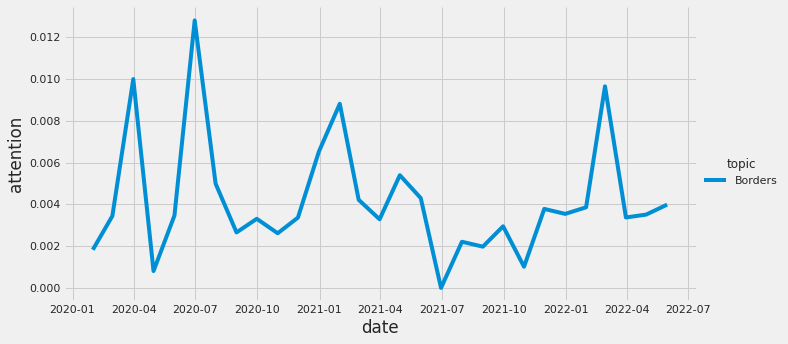

```python
x = get_proportion_by_keyword(df, 'border', 'Uk Sun', 'M', 'Borders')

sns.relplot(x='date', y='attention', hue='topic', data=x, kind='line', aspect=2)
```

## We can similarly get the weekly values as well:

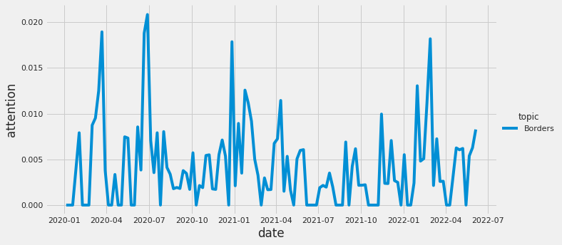

```python
x = get_proportion_by_keyword(df, 'border', 'Uk Sun', 'W', 'Borders')

sns.relplot(x='date', y='attention', hue='topic', data=x, kind='line', aspect=2)
```

# Worked Example #4 – comparing attention to different issues by different newspapers

## In this example, I’ll show how to use the functions from this notebook to compare the attention of different newspapers to different issues. This one is a bit more complex, so feel free to reach out if you have trouble.

First I need to identify the keywords related to vaccines. I’ll use a few for each language and store them as lists:

```python
## example:
german_keywords = ['impfung', 'impfimpfung', 'impfen']
```

```python
german_keywords = ['impfung', 'impfimpfung', 'impfen']
```

Then I can create new datasets for all the newspapers in Germany. I’ll do this by using the `get_titles_by_keyword` function and pass in the country so that it returns all the German newspapers:

```python
#example:
get_titles_by_keyword(dataset = df, keywords = german_keywords, country = 'Germany')
```

which provides the following:

```python
get_titles_by_keyword(dataset = df, keywords = german_keywords, country = 'Germany')
```

|  | date | link | title | newspaper | country |
| --- | --- | --- | --- | --- | --- |
| 867760 | 2022-12-29 | https://www.sueddeutsche.de/bayern/bayern-coro... | Bilanz : Bayerns Impfzentren schließen zum Jah... | Suddeutsche Zeitung | Germany |
| 867804 | 2022-12-08 | https://www.sueddeutsche.de/gesundheit/china-c... | Sars-CoV-2 : Heftige Infektionswelle in China ... | Suddeutsche Zeitung | Germany |
| 867873 | 2022-11-22 | https://www.sueddeutsche.de/politik/impfpflich... | Corona-Pandemie : Pfleger und Ärzte brauchen k... | Suddeutsche Zeitung | Germany |
| 867881 | 2022-11-17 | https://www.sueddeutsche.de/gesundheit/kinder-... | Stiko-Empfehlung : Gesunde Kleinkinder brauche... | Suddeutsche Zeitung | Germany |
| 867885 | 2022-11-16 | https://www.sueddeutsche.de/gesundheit/guertel... | Nebenwirkungen der Covid-Impfung? : Verdachtsf... | Suddeutsche Zeitung | Germany |
| ... | ... | ... | ... | ... | ... |
| 1684082 | 2022-04-13 | https://www.bild.de/bild-plus/ratgeber/psychol... | Psychische Form von Gewalt: Schweigen ist grau... | Bild | Germany |
| 1693094 | 2022-05-24 | https://www.bild.de/ratgeber/2022/ratgeber/cov... | Covid19-Empfehlung der Stiko - Gesunde Kinder ... | Bild | Germany |
| 1696690 | 2022-06-11 | https://www.bild.de/bild-plus/ratgeber/kind-fa... | Kinder: Was Sie nach dem Schimpfen immer tun s... | Bild | Germany |
| 1698376 | 2022-06-19 | https://www.bild.de/ratgeber/2022/ratgeber/usa... | USA impfen Kleinste gegen Corona - Corona-Piks... | Bild | Germany |
| 1699624 | 2022-06-25 | https://www.bild.de/regional/leipzig/leipzig-n... | Impfen: Neuer Stichtags-Ärger bei Kliniken und... | Bild | Germany |

5218 rows × 5 columns

I’ll store that dataset of german headlines about vaccines with a new variable called: `germany_vaccines`

```python
#example
germany_vaccines = get_titles_by_keyword(dataset = df, keywords = german_keywords, country = 'Germany')
```

We’ll then use the new dataset to get the sentiment of each article using the `sentiment_analysis` function from above and storing the dataset as another variable called `sentiment_germany_vaccines`:

```python
#example
sentiment_germany_vaccines = sentiment_analysis(germany_vaccines)
```

This will take a few minutes, because we are using the language model to classify each of the 5,000+ headlines about vaccines in Germany. In the code below, I’ll only classify 100 of the articles so it doesn’t take too long. I’ll note this in the code block below.

Here’s what we’ll get if we view that new dataset:

```python
germany_vaccines = get_titles_by_keyword(dataset = df, keywords = german_keywords, country = 'Germany')

germany_vaccines = germany_vaccines.sample(100) ## we'll only use a sample of 100 so it doesn't take a long time to classify all the headlines

sentiment_germany_vaccines = sentiment_analysis(germany_vaccines)
```

```python
sentiment_germany_vaccines
```

|  | date | link | title | newspaper | country | sentiment | sentiment_label |
| --- | --- | --- | --- | --- | --- | --- | --- |
| 1550289 | 2020-08-27 | https://www.bild.de/ratgeber/kind-familie/kind... | Schwangerschaftsvorsorge: Diese Tests und Impf... | Bild | Germany | {'label': 'positive', 'score': 0.8691583275794... | positive |
| 1008620 | 2020-07-30 | https://www.sueddeutsche.de/bayern/augsburg-ge... | 1200 Euro Strafe für Beschimpfung | Suddeutsche Zeitung | Germany | {'label': 'negative', 'score': 0.9986043572425... | negative |
| 1599980 | 2021-03-19 | https://www.bild.de/ratgeber/gesundheit/gesund... | Corona-Impfungen: Was ist, wenn der Körper hef... | Bild | Germany | {'label': 'positive', 'score': 0.5470689535140... | positive |
| 1331921 | 2021-12-03 | https://www.sueddeutsche.de/gesundheit/gesundh... | Kinderimpfungen sollen noch vor Weihnachten st... | Suddeutsche Zeitung | Germany | {'label': 'positive', 'score': 0.6316090226173... | positive |
| 1567502 | 2020-11-09 | https://www.bild.de/regional/muenchen/muenchen... | „So rasch wie möglich“ - Bayern bereitet sich ... | Bild | Germany | {'label': 'negative', 'score': 0.612501323223114} | negative |
| ... | ... | ... | ... | ... | ... | ... | ... |
| 1614364 | 2021-05-21 | https://www.bild.de/regional/muenchen/muenchen... | Zecken-Impfung: Darf ich mich gegen Corona und... | Bild | Germany | {'label': 'positive', 'score': 0.6395680904388... | positive |
| 1186350 | 2021-04-21 | https://www.sueddeutsche.de/gesundheit/gesundh... | Corona-Impfungen für Altersgruppe 60+ an Woche... | Suddeutsche Zeitung | Germany | {'label': 'positive', 'score': 0.8272635340690... | positive |
| 1152155 | 2021-03-05 | https://www.sueddeutsche.de/bayern/gesundheit-... | Bayerns große Konzerne zum Impfen bereit | Suddeutsche Zeitung | Germany | {'label': 'positive', 'score': 0.8605371117591... | positive |
| 1151204 | 2021-02-22 | https://www.sueddeutsche.de/gesundheit/gesundh... | Medizinisches Personal erhält Corona-Schutzimp... | Suddeutsche Zeitung | Germany | {'label': 'positive', 'score': 0.7818202972412... | positive |
| 1608490 | 2021-04-26 | https://www.bild.de/ratgeber/2021/ratgeber/imp... | Corona-Impfung: Löst Biontech Herzprobleme aus... | Bild | Germany | {'label': 'negative', 'score': 0.9988648891448... | negative |

100 rows × 7 columns

If we want to see the totals of how many positive, negative and neutral headlines about vaccines by newspapers:

```python
sentiment_germany_vaccines.groupby(['newspaper', 'sentiment_label']).size()
```

```
newspaper            sentiment_label
Bild                 negative           13
                     neutral             6
                     positive            5
De Welt              negative            2
                     neutral             3
                     positive            1
Suddeutsche Zeitung  negative           15
                     neutral            24
                     positive           31
dtype: int64
```

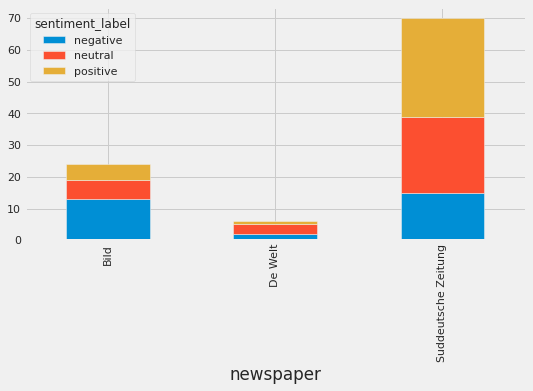

```python
sentiment_germany_vaccines.groupby(['newspaper', 'sentiment_label']).size().unstack().plot(kind='bar', stacked=True, figsize=(8,4))
```

## What if we want to get the attention of the German newspapers to vaccines throughout the pandemic?

For that, we just need to pass in the `german_keywords` to the `get_proportion_by_keywords` function. Because the function requires the newspapaer name, we’ll create three separate datasets for each of the German newspapers:

Remember, the German newspapers are: Suddeutsche Zeitung, De Welt, and Bild

```python
attention_SZ = get_proportion_by_keyword(df, keywords = german_keywords, newspaper = 'Suddeutsche Zeitung', frequency = 'M', topic = 'Vaccines')
attention_DW = get_proportion_by_keyword(df, keywords = german_keywords, newspaper = 'De Welt', frequency = 'M', topic = 'Vaccines')
attention_Bild = get_proportion_by_keyword(df, keywords = german_keywords, newspaper = 'Bild', frequency = 'M', topic = 'Vaccines')
```

Now we can plot the attention to vaccines by any of the newspapers:

```python
attention_SZ = get_proportion_by_keyword(df, keywords = german_keywords, newspaper = 'Suddeutsche Zeitung', frequency = 'M', topic = 'Vaccines')
attention_DW = get_proportion_by_keyword(df, keywords = german_keywords, newspaper = 'De Welt', frequency = 'M', topic = 'Vaccines')
attention_Bild = get_proportion_by_keyword(df, keywords = german_keywords, newspaper = 'Bild', frequency = 'M', topic = 'Vaccines')
```

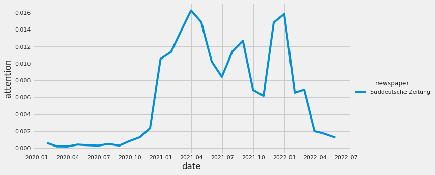

```python
sns.relplot(x='date', y='attention', hue='newspaper', data=attention_SZ, kind='line', aspect=2)
```

#### What if we want to plot them all in the same graph?

We can combine the datasets and then re-create the same plot:

```python
# combine dataset:
german_newspapers_combined = pd.concat([attention_SZ, attention_DW, attention_Bild])
# reset index
german_newspapers_combined.reset_index(inplace=True)
# recreate plot:
sns.relplot(x='date', y='attention', hue='newspaper', data = german_newspapers_combined, kind='line', aspect=2)
# add title (optional)
plt.title('Attention to Vaccines in German Newspapers')
```

which gives the following result:

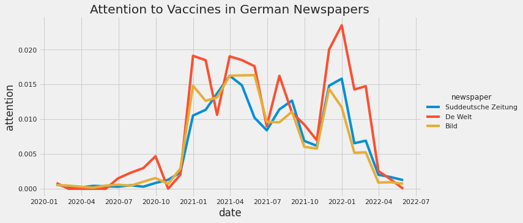

```python
german_newspapers_combined = pd.concat([attention_SZ, attention_DW, attention_Bild])
## reset index
german_newspapers_combined.reset_index(inplace=True)
#recreate plot:
sns.relplot(x='date', y='attention', hue='newspaper', data = german_newspapers_combined, kind='line', aspect=2)
# add title (optional)
plt.title('Attention to Vaccines in German Newspapers')
```

# Worked Example #5: Borders analysis for WP1

## In this final tutorial, I’ll conduct the borders analysis per the request of WP1. I won’t walk through all the code, but I’ll use the same functions and methods that I’ve created throughout the notebook

```python
german = ['grenz','schengen','Reisebeschränkung', 'Reiseverbot', 'Einreiseverbot', 'Mobilitätsbeschränkung',  'Schlagbaum']
polish = ['granica', 'Schengen', 'ograniczenie', 'zakaz',  'podróży', 'Zakazy', 'mobilności', 'szlaban']
spanish = ['front','schengen','restriccion','prohibición', 'prohibiciones','movilidad']
dutch = ['grens','schengen','reisbeperking', 'reisverbod', 'inreisverbod', 'mobilititeitsbeperking',  'slagboom']
english = ['border','schengen','restriction','prohibition', 'prohibitions','mobility','travel ban','entry ban']

dic = {'Poland': 'polish', 'Germany': 'german', 'Spain': 'spanish', 'Netherlands': 'dutch', 'UK': 'english'}
df['language'] = df['country'].map(dic)
```

```python
languages = ['german', 'polish', 'spanish', 'dutch', 'english']


attn= pd.DataFrame()

for language in languages:
    for newspaper in df.loc[df.language == language].newspaper.unique():
        try:
            attention = get_proportion_by_keyword(df, keywords = eval(language), newspaper = newspaper, frequency = 'M', topic = 'Borders')
            attention['country'] = language
            attn = pd.concat([attn, attention])
        except TypeError:
            pass


attn=attn.reset_index(drop=True)
lang_to_country = {'german': 'Germany', 'polish': 'Poland', 'spanish': 'Spain', 'dutch': 'Netherlands', 'english': 'UK'}
attn['country'] = attn['country'].map(lang_to_country)
```

```
Your query did not return anything. Make sure that the country, newspaper, and dates are correct. Did you give a start date that is later than the end date?
 ---
The optional newspapers are: ['Fakt' 'Rzeczpospolita' 'Gazeta Wyborcza' 'Uk Times' 'Guardian' 'Uk Sun'
 'Nrc' 'De Telegraaf' 'Volkskrant' 'El Mundo' 'El Pais' 'Abc Spain'
 'Suddeutsche Zeitung' 'De Welt' 'Bild']
```

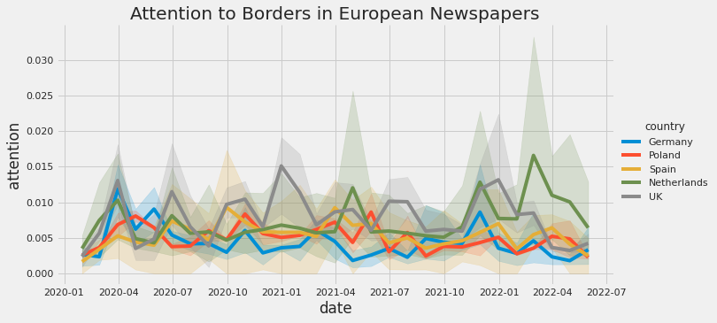

```python
sns.relplot(x='date', y='attention', hue='country', data=attn, kind='line', aspect=2)
plt.title('Attention to Borders in European Newspapers')
```

```python
### Let's get the sentiment of the headlines that contain the keywords over time


languages = ['german', 'polish', 'spanish', 'dutch', 'english']


attn1= pd.DataFrame()

for newspaper in df.newspaper.unique():
    try:
        lang = df.loc[df.newspaper == newspaper].language.unique()[0]
        attention = get_titles_by_keyword(df, keywords = eval(lang), newspaper = newspaper)
        attention['newspaper'] = newspaper
        attn1 = pd.concat([attn1, attention])
    except TypeError:
        pass
```

```
Your query did not return anything. Make sure that the country, newspaper, and dates are correct. Did you give a start date that is later than the end date?
 ---
The optional newspapers are: ['Fakt' 'Rzeczpospolita' 'Gazeta Wyborcza' 'Uk Times' 'Guardian' 'Uk Sun'
 'Nrc' 'De Telegraaf' 'Volkskrant' 'El Mundo' 'El Pais' 'Abc Spain'
 'Suddeutsche Zeitung' 'De Welt' 'Bild']
```

```python
attn1 = attn1.reset_index(drop=True)
attn1 = attn1.sample(100) ### we'll only take a sample of 100 of these headlines so it doesn't take too long
attn1 = sentiment_analysis(attn1)
```

```python
attn1['sentiment_centered'] = pd.Categorical(attn1.sentiment_label, categories=['negative', 'neutral', 'positive'], ordered=True).codes - 1
```

```python
attn1.groupby(['newspaper', 'sentiment_label']).size().unstack().plot(kind='bar', stacked=True, figsize=(8,4))
plt.title('Sentiment of Headlines about Borders in European Newspapers')
```

[output not shown]

```python
attn2 = attn1.groupby(['newspaper','country', pd.Grouper(key='date', freq='M')]).mean().reset_index()
attn2 = attn2.query('date > "2020-01-01" and date < "2022-05-31"')
```

```python
sns.relplot(x='date', y='sentiment_centered', hue='country', data=attn2, kind='line', aspect=2)
plt.title('Dynamic Sentiment of Headlines about Borders in European Newspapers')
```

[output not shown]

## How do I use the GPU in Google Colab if I need to get the sentiment for a lot of newspaper headlines?

Classifying the sentiment of the headlines can take a long time. For example, the ~5k German vaccines headlines took about 5 minutes. This poses a big challenge if we want to classify many more headlines.

One alternative is to use a GPU for the matrix multiplication that occurs billions of times when using transformers models. CPUs are not very good at this task, so using a GPU can be **MUCH** faster. Luckily, Google Colab allows free use of GPUs. Google Colab is probably the best way to run this entire notebook just because Python seems to be challenging for a lot of people to get install locally, so even if you don’t want to use a GPU, Google Colab might be the best option.

Google has a tutorial on how to use a GPU in Colab [here](https://colab.research.google.com/notebooks/gpu.ipynb). Once you enable the GPU, the only change you’ll need to make to the language is model is to add in `device=0` when defining the classifier. This would look like the following:

```python
sentiment_classifier = TextClassificationPipeline(tokenizer=tokenizer, model=m1, device=0)  ## add in device=0 to use the GPU
```

instead of this:

```python
sentiment_classifier = TextClassificationPipeline(tokenizer=tokenizer, model=m1)  ## uses the slower CPU
```